# Números naturales

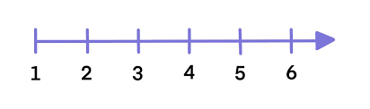

Son los que usamos para contar.

❗ No se usa calculadora: primero hay que entrenar la mente y lograr automatismos para pensar y resolver mejor.

## Operaciones básicas

Los números naturales son aquellos que sirven para contar cosas, por ejemplo 2 manzanas, 8 autos, etc. Empiezan en 1 y no tienen fin, es decir son infinitos.

### 1. Sumas y restas (Alternancia 1)

Recuerda que para sumar o restar los números se acomodan empezando por la derecha.

**Ejercicios**

Sumas

1. 250 + 36 + 590 =
2. 299 + 456 + 359 =
3. 3245 + 160 + 1232 =
4. 4250 + 123 + 3590 =
5. 3250 + 360 + 4564 =

Restas

6. 256 - 86 =
7. 509 - 456 =
8. 1258 - 160 =
9. 1364 - 623 =
10. 6255 - 2345 =

**Problemas**

1. En una biblioteca hay 235 libros. LLegan 48 libros nuevos y luego se prestan 63. ¿Cuántos libros quedan en la biblioteca?
2. Un colectivo lleva 37 pasajeros . En la siguiente parada suben 15 personas y bajan 22. ¿Cuántos pasajeros quedan en el colectivo?
3. en una campaña solidaria una escuela juntó alimentos durante tres días: el lunes juntaron 248 paquetes, el martes juntaron 176 paquetes más que el lunes, el miércoles juntaron 95 paquetes menos que el martes. Durante la semana repartieron 389 paquetes. ¿Cuántos paquetes quedaron al final?

### 2. Multiplicaciones y divisiones

Si no te acuerdas como se hacen repasa con estos videos:

- [Multiplicación](https://www.youtube.com/watch?v=zTUSsWJDqZk)
- [División por una cifra](https://www.youtube.com/watch?v=4froVZh9KWE)
- [División por una dos cifras](https://www.youtube.com/watch?v=CLV2SyZn5JU)

**Ejercicios**

De ahora en adelante usamos el punto “·” para indicar una multiplicación y la barra inclinada “/” indicar una división.

Pueden hacerse estas o las que se pusieron en el pizarrón en clase

```
Multiplicaciones   Divisiones

1) 435 · 7 =       1) 245 / 4 =
2) 9763 · 3 =      2) 3456 / 3 =
3) 23456 · 35 =    3) 29753 / 47 =
```

### 3. Práctica especial de divisiones (Alternancia 2)

**Ejercicios**

1. 42600 / 3 =
2. 12150 / 30 =
3. 416602 / 21 =
4. 583 / 6 =
5. 123450 / 40 =
6. 5912340 / 5 =
7. 45240 / 90 =
8. 54210 / 150 =
9. 11204 / 25 =
10. 485721 / 11 =

**Problemas**

1. Una caja tiene 6 paquetes y cada paquete tiene 4 galletitas. Si se reparten en partes iguales entre 3 chicos, ¿cuántas galletitas recibe cada uno?
2. En una excursión, 8 grupos de alumnos juntan en total 960 tapitas. Cada grupo reparte sus tapitas en partes iguales entre 5 bolsas. Luego, todas las bolsas se juntan y se reparten en partes iguales entre 10 alumnos. ¿Cuántas tapitas recibe cada alumno?

### 4. Multiplicación y división por la unidad seguida de ceros

**Idea clave** - Multiplicar por 10, 100, 1000, … → agregar ceros al final. **Ej.** 43 · 100 = 4.300 - Dividir por 10, 100, 1000, … → quitar cifras desde el final. **Ej.** 23000 / 1000 = 23

**Ejercicios**

Multiplicación

1. $23 \cdot 10$
2. $47 \cdot 100$
3. $305 \cdot 1000$
4. $9 \cdot 10000$

División

1. $540 \div 10$
2. $7200 \div 100$
3. $63000 \div 1000$
4. $900 \div 100$

## Divisibilidad

### 5. Divisibilidad, múltiplos y divisores

- Un número es divisible por otro si la división es exacta (resto 0). **Ej.** 20 es divisible por 5 por que 20/5 da exacto.
- *Múltiplos*: **Ej.** 16 es múltiplo de 2 por que viene de multiplicar 2 por 8.
- *Divisores*: **Ej.** 3 es divisor de 9 por que 9 dividido en 3 es exacto.

**Ejercicios**

Completar poniendo una sola palabra en cada raya

1. 45 es divisible por 5 porque si ___ 45 en 5 el resto es ___.
2. 36 es múltiplo de 4 porque si ___ 4 por 9 me da ____.
3. 7 es divisor de 21 porque si ___ 21 en ___ la división es exacta.
4. Dar 3 ejemplos de números divisibles por 4
5. Dar 3 ejemplo de números divisibles por 11
6. Dar 3 ejemplos de múltiplos de 9

### 6. Criterios de divisibilidad

Te ayudan a descubrir fácilmente si un número es divisible por 2, 3, 5 y 10

- Por 2: un número es divisible por 2 si termina en 0, 2, 4, 6 u 8 (es decir es par).
- Por 3: un número es divisible por 3 si la suma de sus cifras es múltiplo de 3.
- Por 5: un número es divisible por 5 si termina en 0 o 5.
- Por 10: un número es divisible por 10 si termina en 0.

**Ejercicios**

1. Dar 3 ejemplos de números de 4 cifras divisibles por 2
2. Dar 3 ejemplos de números de 4 cifras divisibles por 3
3. Dar 3 ejemplos de números que son divisibles al mismo tiempo por 2 y por 5
4. Dar 3 ejemplos de números de 4 cifras divisibles por 3 y por 5
5. Escribir todos los números entre 100 y 120 divisibles por 3 y por 2 (al mismo tiempo)
6. Escribir todos los números entre 250 y 300 divisibles por 3 y 5

### 7. Números primos

- *Primos*: tienen solo dos divisores (1 y él mismo).
- *Compuestos*: tienen más divisores.

**Ejercicios**

1. Encontrar y escribir todos los números primos entre 1 y 20
2. Pensar si el número 48 es primo o compuesto y porque
3. Pensar si el número 3150201 es primo y porque